# R Notebook

# Heatmap

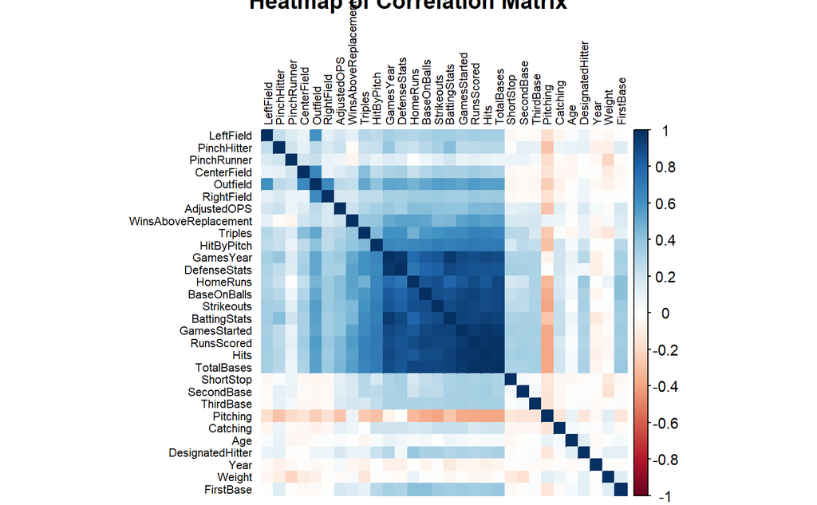

```r
corrplot(cor_data, method = "color", order = "hclust", tl.cex = 0.6,
         title = "Heatmap of Correlation Matrix",
         tl.col = "black", tl.srt = 90)
```

As we can see, WAR isn’t highly correlated to one feature.

# PCA

```r
pca_model <- prcomp(data[, sapply(data, is.numeric)], center = TRUE, scale. = TRUE)
summary(pca_model)
```

```
Importance of components:
                          PC1    PC2     PC3     PC4     PC5     PC6     PC7     PC8     PC9    PC10    PC11
Standard deviation     2.9363 1.4063 1.23170 1.19183 1.04998 1.02869 0.98826 0.97728 0.97004 0.94693 0.94342
Proportion of Variance 0.3592 0.0824 0.06321 0.05919 0.04594 0.04409 0.04069 0.03979 0.03921 0.03736 0.03709
Cumulative Proportion  0.3592 0.4416 0.50484 0.56403 0.60996 0.65406 0.69475 0.73455 0.77375 0.81112 0.84820
                          PC12    PC13    PC14    PC15    PC16    PC17    PC18    PC19    PC20    PC21    PC22
Standard deviation     0.90940 0.85516 0.84741 0.83768 0.71877 0.24055 0.19845 0.14369 0.13441 0.08661 0.05498
Proportion of Variance 0.03446 0.03047 0.02992 0.02924 0.02153 0.00241 0.00164 0.00086 0.00075 0.00031 0.00013
Cumulative Proportion  0.88266 0.91313 0.94305 0.97229 0.99382 0.99623 0.99787 0.99873 0.99948 0.99979 0.99992
                          PC23    PC24
Standard deviation     0.03694 0.02400
Proportion of Variance 0.00006 0.00002
Cumulative Proportion  0.99998 1.00000
```

- The first principal component captures 35.92% of the variance within the dataset, highlighting its significant role in encompassing the key features and variations of the data.
- By retaining the first 10 principal components, which cumulatively account for over 81% of the dataset’s variance, we can effectively reduce dimensionality while preserving the majority of the information.
- The rapid decline in the proportion of variance explained by subsequent components beyond the 15th (reaching nearly 97.23% cumulative variance), suggests that further components contribute minimally to the data’s overall structure.
- These results support using the top 10 to 15 components for further data analysis, simplifying the computational demands and potentially enhancing the clarity of patterns and trends in the data.

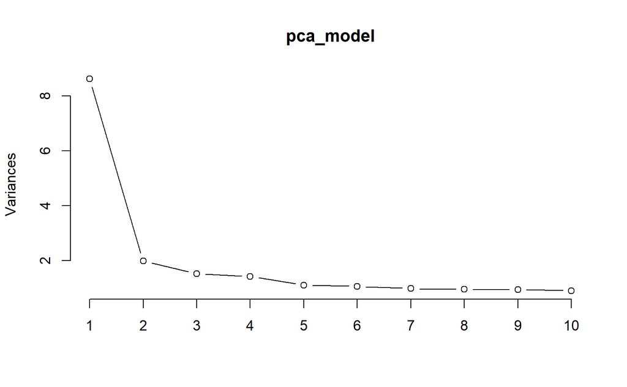

```r
plot(pca_model, type = "l")
```

# Step 2: Exploratory Data Analysis (EDA)

## Descriptive Statistics:

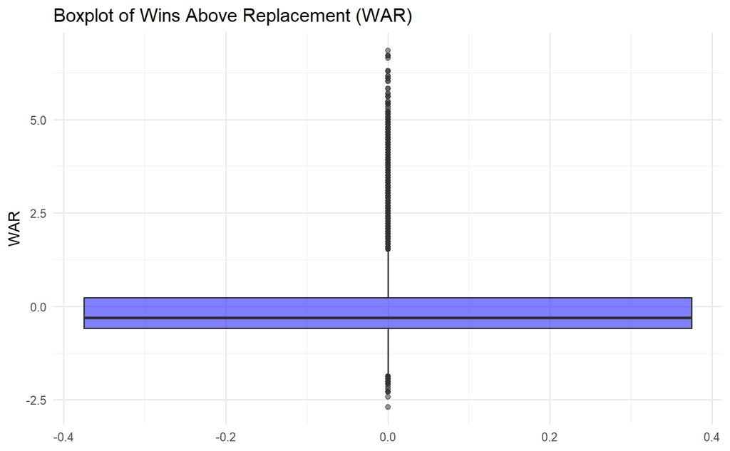

```r
library(ggplot2)

# Boxplot for Wins Above Replacement (WAR)
ggplot(data, aes(y = WinsAboveReplacement)) +
  geom_boxplot(fill = "blue", alpha = 0.5) +
  theme_minimal() +
  labs(title = "Boxplot of Wins Above Replacement (WAR)", y = "WAR")
```

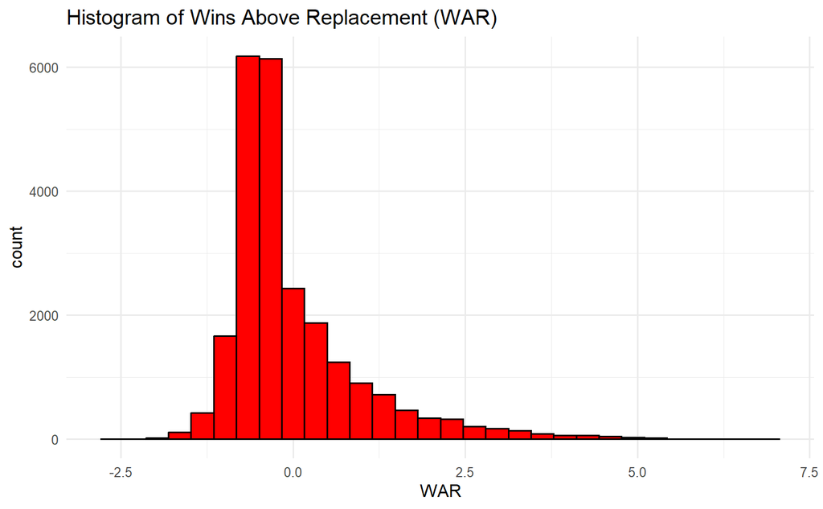

```r
# Histogram for Wins Above Replacement (WAR)
ggplot(data, aes(x = WinsAboveReplacement)) +
  geom_histogram(bins = 30, fill = "red", color = "black") +
  theme_minimal() +
  labs(title = "Histogram of Wins Above Replacement (WAR)", x = "WAR")
```

### For other continuous variables (example: TotalBases)

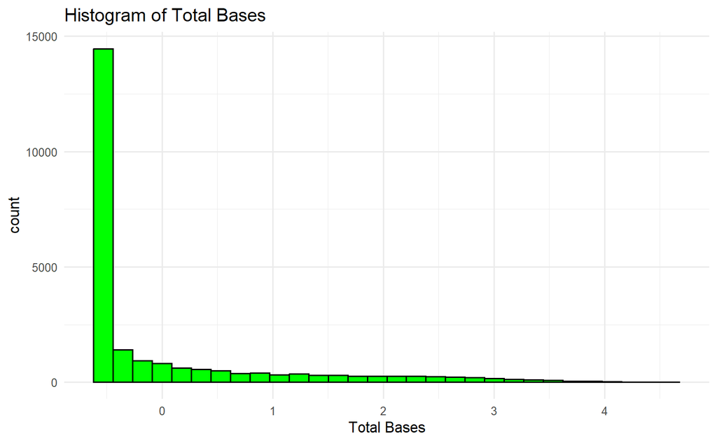

```r
ggplot(data, aes(x = TotalBases)) +
  geom_histogram(bins = 30, fill = "green", color = "black") +
  theme_minimal() +
  labs(title = "Histogram of Total Bases", x = "Total Bases")
```

### Compute 5-Number Summaries

```r
# Selecting only continuous variables for summary
continuous_vars <- data[, sapply(data, is.numeric)]
summary(continuous_vars)
```

```
      Year           RunsScored           Hits          AdjustedOPS          TotalBases          Weight
 Min.   :-1.6790   Min.   :-0.5730   Min.   :-0.5898   Min.   :-2.087072   Min.   :-0.5769   Min.   :-3.4075
 1st Qu.:-0.8146   1st Qu.:-0.5730   1st Qu.:-0.5898   1st Qu.:-0.004536   1st Qu.:-0.5769   1st Qu.:-0.5785
 Median : 0.0499   Median :-0.5323   Median :-0.5681   Median : 0.000000   Median :-0.5507   Median :-0.1070
 Mean   : 0.0000   Mean   : 0.0000   Mean   : 0.0000   Mean   : 0.000000   Mean   : 0.0000   Mean   : 0.0000
 3rd Qu.: 0.9144   3rd Qu.: 0.1198   3rd Qu.: 0.1689   3rd Qu.: 0.544240   3rd Qu.: 0.1309   3rd Qu.: 0.6003
 Max.   : 1.5627   Max.   : 5.4993   Max.   : 4.2877   Max.   :16.036614   Max.   : 4.5479   Max.   : 4.8439
   GamesYear        GamesStarted      BattingStats      DefenseStats        Pitching          Catching
 Min.   :-1.0392   Min.   :-0.6964   Min.   :-0.8148   Min.   :-1.0109   Min.   :-0.6810   Min.   :-0.2172
 1st Qu.:-0.7657   1st Qu.:-0.6964   1st Qu.:-0.7724   1st Qu.:-0.7652   1st Qu.:-0.6810   1st Qu.:-0.2172
 Median :-0.3554   Median :-0.4886   Median :-0.4539   Median :-0.3474   Median :-0.5761   Median :-0.2172
 Mean   : 0.0000   Mean   : 0.0000   Mean   : 0.0000   Mean   : 0.0000   Mean   : 0.0000   Mean   : 0.0000
 3rd Qu.: 0.4651   3rd Qu.: 0.2040   3rd Qu.: 0.4591   3rd Qu.: 0.4635   3rd Qu.: 0.4197   3rd Qu.:-0.2172
 Max.   : 2.6759   Max.   : 3.0668   Max.   : 2.6461   Max.   : 2.9699   Max.   : 4.1410   Max.   : 8.9544
   FirstBase         SecondBase        ThirdBase        ShortStop         LeftField        CenterField
 Min.   :-0.2045   Min.   :-0.2123   Min.   :-0.211   Min.   :-0.1909   Min.   :-0.2531   Min.   :-0.2097
 1st Qu.:-0.2045   1st Qu.:-0.2123   1st Qu.:-0.211   1st Qu.:-0.1909   1st Qu.:-0.2531   1st Qu.:-0.2097
 Median :-0.2045   Median :-0.2123   Median :-0.211   Median :-0.1909   Median :-0.2531   Median :-0.2097
 Mean   : 0.0000   Mean   : 0.0000   Mean   : 0.000   Mean   : 0.0000   Mean   : 0.0000   Mean   : 0.0000
 3rd Qu.:-0.2045   3rd Qu.:-0.2123   3rd Qu.:-0.211   3rd Qu.:-0.1909   3rd Qu.:-0.2531   3rd Qu.:-0.2097
 Max.   : 8.9775   Max.   : 9.2710   Max.   : 9.197   Max.   : 8.6965   Max.   :10.0167   Max.   : 9.1447
   RightField         Outfield       DesignatedHitter   PinchHitter        PinchRunner     WinsAboveReplacement
 Min.   :-0.2257   Min.   :-0.3625   Min.   :-0.2037   Min.   :-0.43672   Min.   :-0.308   Min.   :-2.6927
 1st Qu.:-0.2257   1st Qu.:-0.3625   1st Qu.:-0.2037   1st Qu.:-0.43672   1st Qu.:-0.308   1st Qu.:-0.5803
 Median :-0.2257   Median :-0.3625   Median :-0.2037   Median :-0.43672   Median :-0.308   Median :-0.3077
 Mean   : 0.0000   Mean   : 0.0000   Mean   : 0.0000   Mean   : 0.00000   Mean   : 0.000   Mean   : 0.0000
 3rd Qu.:-0.2257   3rd Qu.:-0.3625   3rd Qu.:-0.2037   3rd Qu.:-0.05141   3rd Qu.:-0.308   3rd Qu.: 0.2374
 Max.   : 9.5269   Max.   : 5.0345   Max.   :15.2656   Max.   :13.56270   Max.   :18.520   Max.   : 6.8471
```

### Findings:

- **Performance Variability**: There is considerable variability in player performance across different metrics, with a few outliers significantly outperforming others.
- **Skewness in Distributions**: Many of the metrics show right-skewed distributions, where the majority of players are below the average, pulled up by high-performing outliers.
- **Physical and Role Diversity**: The wide range in physical stats (like Weight) and role-specific stats (like Games Started or Pitching) reflects the diversity in player roles and physical builds, emphasizing the varied nature of professional baseball.
- **Impact Players**: The range in Wins Above Replacement highlights the presence of both underperformers and impact players within the league, showcasing the potential for significant individual contributions to team success.

# Step 3: Answering Specific Questions

## Correlation with Team Success

```r
# Assuming 'team_wins', 'playoff_appearances', and 'championships' are in your dataset
# Calculate Spearman's correlation
correlations <- cor(data[c("WinsAboveReplacement", "team_wins", "playoff_appearances", "championships")],
                    method = "spearman", use = "complete.obs")
```

[output not shown]